# Effect of Ranking Indicators on University Ranking (QS University Ranking 2023)

## Investigation Overview

The aim is to investigate the QS University Ranking and the impact of the six ranking indicators among Universities using the QS University Ranking 2023 as a case study.

## Dataset Overview

The Dataset consists of 1422 Universities across the globe. the dataset has 21 columns, but the emphasise is on the six ranking indicators (ar score, er score, fsr score, isr score, ifr score, cpf score), location, institution and the ranking.

# What are the Countries with the Most ranked Universities?

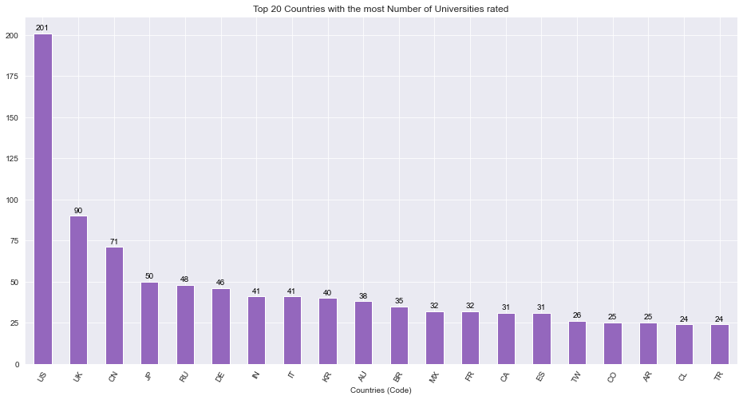

# Distribution of Academic reputation score

The academic reputation score has a value that ranges from 0-100, when plot on a logarithmic scale it has a unimodal shape, with one peak value between 4 and 5 roughly.

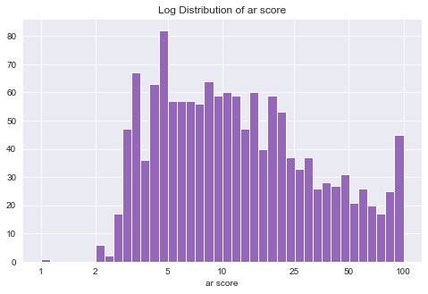

# Distribution of Employment reputation score

The employment reputation score has a value that ranges from 0-100, when plot on a logarithmic scale it has a unimodal shape.

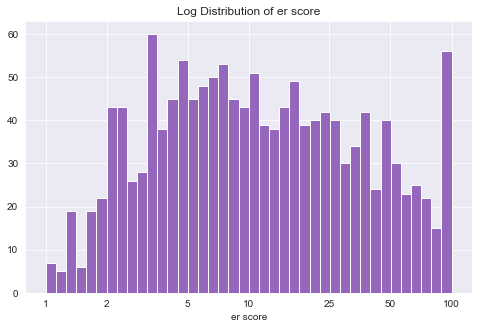

### ...The remaining ranking indicators are Unimodal in shape

# Employment Reputation vs Academic reputation

When plotted on a log scale there's a clear Linear relationship between academic reputation (ar score) and employment reputation(er score) when the points are zoom in the third subplot. where we can see that a high ar score result in higher er score. we can expect high er score will result in high ar score.

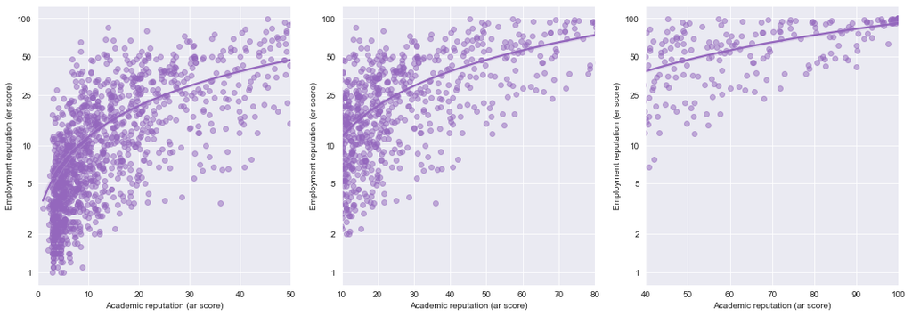